# Histopath_Cancer_ID

```python
from google.colab import drive
drive.mount('/content/gdrive')
```

```python
! pip install -q kaggle

! pip install --upgrade --force-reinstall --no-deps kaggle
```

```
     |████████████████████████████████| 61kB 5.0MB/s eta 0:00:011
  Found existing installation: kaggle 1.5.12
    Uninstalling kaggle-1.5.12:
      Successfully uninstalled kaggle-1.5.12
```

```python
! mkdir ~/.kaggle

! cp kaggle.json ~/.kaggle/

! chmod 600 ~/.kaggle/kaggle.json

! kaggle competitions download -c histopathologic-cancer-detection
```

```
Downloading histopathologic-cancer-detection.zip to /content
100% 6.28G/6.31G [01:12<00:00, 97.6MB/s]
100% 6.31G/6.31G [01:12<00:00, 93.3MB/s]
```

```python
#@title Unzip
# Unzip and load the dataset onto your current directory

import zipfile

zip = zipfile.ZipFile('histopathologic-cancer-detection.zip')

zip.extractall()
```

# Brief description of the problem and data

## Goal

The goal of this project is to use ML techniques, specifically CNNs, to identify metastatic cancer in small image patches taken from larger digital pathology scans. The image data had labels 1 and 0, cancer or no cancer. A dataset of unlabeled images is provided to test the model.

## What is this cancer and why is it important to detect?

Cancer is a massive killer, claiming close to 2 million lives in 2020. The National Cancer Institute defines histopathology as "the study of diseased cells and tissues using a microscope."Histology is the study of tissues, and pathology is the study of disease. So taken together, histopathology literally means the study of tissues as relates to disease. (Source: Verywell Health) A tool that can quickly identify cancer cells can help doctors diagnose and treat cancer faster.

# Exploratory Data Analysis

## How many images in train and test set?

```python
import numpy as np
import pandas as pd
import os
import cv2
import matplotlib.pyplot as plt
import matplotlib.patches as patches
import random
import tensorflow as tf
from tensorflow import keras
from tensorflow.keras import layers
```

```python
#https://stackoverflow.com/questions/2632205/how-to-count-the-number-of-files-in-a-directory-using-python
path, dirs, files = next(os.walk("../content/test/"))
file_count = len(files)
print(file_count)
```

```
57458
```

```python
path, dirs, files = next(os.walk("../content/train/"))
file_count = len(files)
print(file_count)
```

```
220025
```

## What is cancer non cancer split of train set?

```python
#https://towardsdatascience.com/upgrade-your-image-classifier-with-balanced-data-ddea93859c0f
df_data = pd.read_csv('../content/train_labels.csv')

# Check the class distribution

print(df_data['label'].value_counts())
```

```
0    130908
1     89117
Name: label, dtype: int64
```

The split is not 50/50, we will use a sample size from each set of 80,000 so we have a balance.

## Size and dimension of images?

```python
img = cv2.imread("../content/train/00001b2b5609af42ab0ab276dd4cd41c3e7745b5.tif")
img.shape
```

```
(96, 96, 3)
```

## Image Visualization, Cancer vs Not

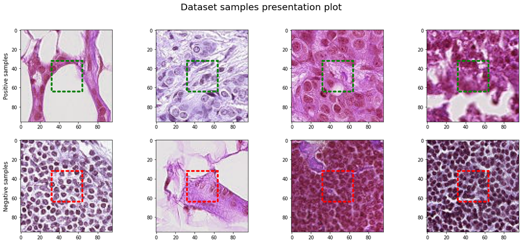

```python
# There are many existing implementations of this visualization, I chose the to use the following source:
# https://www.kaggle.com/syedaar/histopathologic-cancer-detection-using-tensorflow
train_dirname = "../content/train/"
positive_samples = df_data.loc[df_data['label'] == 1].sample(4)
negative_samples = df_data.loc[df_data['label'] == 0].sample(4)
positive_images = []
negative_images = []
for sample in list(positive_samples['id']):
    path = os.path.join(train_dirname, sample+'.tif')
    img = cv2.imread(path)
    positive_images.append(img)

for sample in list(negative_samples['id']):
    path = os.path.join(train_dirname, sample+'.tif')
    img = cv2.imread(path)
    negative_images.append(img)

fig,axis = plt.subplots(2,4,figsize=(20,8))
fig.suptitle('Dataset samples presentation plot',fontsize=20)
for i,img in enumerate(positive_images):
    axis[0,i].imshow(img)
    rect = patches.Rectangle((32,32),32,32,linewidth=4,edgecolor='g',facecolor='none', linestyle=':', capstyle='round')
    axis[0,i].add_patch(rect)
axis[0,0].set_ylabel('Positive samples', size='large')
for i,img in enumerate(negative_images):
    axis[1,i].imshow(img)
    rect = patches.Rectangle((32,32),32,32,linewidth=4,edgecolor='r',facecolor='none', linestyle=':', capstyle='round')
    axis[1,i].add_patch(rect)
axis[1,0].set_ylabel('Negative samples', size='large')
```

The images in the top row all contain cancerous tumors, while the slide in the bottom row are all negative for cancer. If cancer is present tumors will be inside the 32x32 center region. There are no obvious differences between the images.

## Data Preparation

In the following code the training set is sampled and split into directories for tensorflow processing. The sample size of positive and negative cancer images is 80,000 so that we have a balance (recall the dataset is 60/40 not 50/50). We split out 90% of our sample for training and 10% for validation. The training directory and validation directory each contain two folders with positive and negative images.

```python
#data preparation guide https://towardsdatascience.com/data-preparation-guide-for-detecting-histopathologic-cancer-detection-7b96d6a12004
SAMPLE_SIZE = 80000
# the number of images we use from each of the two classes, allows balance
# take a random sample of class 0 with size equal to num samples in class 1
df_0 = df_data[df_data['label'] == 0].sample(SAMPLE_SIZE, random_state = 101)
# filter out class 1
df_1 = df_data[df_data['label'] == 1].sample(SAMPLE_SIZE, random_state = 101)
# concat the dataframes
df_data = pd.concat([df_0, df_1], axis=0).reset_index(drop=True)
# shuffle
df_data = df_data.sample(frac=1)
```

```python
# #data preparation guide https://towardsdatascience.com/data-preparation-guide-for-detecting-histopathologic-cancer-detection-7b96d6a12004
# split training and validation sets, 90/10.
training_sample_percentage = 0.9
training_sample_size = int(len(df_data)*training_sample_percentage)
validation_sample_size = len(df_data)-training_sample_size

train_df = df_data.sample(n=training_sample_size)
val_df = df_data[~df_data.index.isin(train_df.index)]
```

```python
val_df.head(3)
```

|  | id | label |
| --- | --- | --- |
| 89034 | 96db79539d1b50c60a555434296c4fd5cbb1a350 | 1 |
| 119919 | 8f7e5b464f0d8e5d357c53f9809dbe3ddda7865a | 1 |
| 96576 | 4460a2571d24dc9254e605f6200bd4c363548289 | 1 |

```python
train_df.head(3)
```

|  | id | label |
| --- | --- | --- |
| 25074 | 46ceb354a79861a72d9f990f82ba568455f65ac9 | 0 |
| 4443 | 1de6df99ab6f327cd3482d1486c5729865309b7e | 0 |
| 131520 | f2e20071d99443697f8c1dd68d3a00ee25cd504f | 1 |

```python
train_df.shape
```

```
(144000, 2)
```

```python
val_df.shape
```

```
(16000, 2)
```

```python
##data preparation guide https://towardsdatascience.com/data-preparation-guide-for-detecting-histopathologic-cancer-detection-7b96d6a12004
# Create a new directory
base_dir = 'base_dir'
os.mkdir(base_dir)

#[CREATE FOLDERS INSIDE THE BASE DIRECTORY]
# now we create 2 folders inside 'base_dir':

# train_dir
    # a_no_tumor_tissue
    # b_has_tumor_tissue

# val_dir
    # a_no_tumor_tissue
    # b_has_tumor_tissue

# create a path to 'base_dir' to which we will join the names of the new folders

# train_dir
train_dir = os.path.join(base_dir, 'train_dir')
os.mkdir(train_dir)


# val_dir
val_dir = os.path.join(base_dir, 'val_dir')
os.mkdir(val_dir)


# [CREATE FOLDERS INSIDE THE TRAIN AND VALIDATION FOLDERS]
# Inside each folder we create seperate folders for each class

# create new folders inside train_dir
no_tumor_tissue = os.path.join(train_dir, 'a_no_tumor_tissue')
os.mkdir(no_tumor_tissue)
has_tumor_tissue = os.path.join(train_dir, 'b_has_tumor_tissue')
os.mkdir(has_tumor_tissue)


# create new folders inside val_dir
no_tumor_tissue = os.path.join(val_dir, 'a_no_tumor_tissue')
os.mkdir(no_tumor_tissue)
has_tumor_tissue = os.path.join(val_dir, 'b_has_tumor_tissue')
os.mkdir(has_tumor_tissue)
```

```python
# #data preparation guide https://towardsdatascience.com/data-preparation-guide-for-detecting-histopathologic-cancer-detection-7b96d6a12004
# Set the id as the index in df_data
df_data.set_index('id', inplace=True)
import shutil

# Get a list of train and val images
train_list = list(train_df['id'])
val_list = list(val_df['id'])


# Transfer the train images
count = 0
for image in train_list:
    count += 1
    # the id in the csv file does not have the .tif extension therefore we add it here
    fname = image + '.tif'
    # get the label for a certain image
    target = df_data.loc[image,'label']

    # these must match the folder names
    if target.any() == 0:
        label = 'a_no_tumor_tissue'
    if target.any() == 1:
        label = 'b_has_tumor_tissue'

    # source path to image
    src = os.path.join('../content/train', fname)
    # destination path to image
    dst = os.path.join(train_dir, label, fname)
    # copy the image from the source to the destination
    shutil.copyfile(src, dst)

# Transfer the val images

for image in val_list:

    # the id in the csv file does not have the .tif extension therefore we add it here
    fname = image + '.tif'
    # get the label for a certain image
    target = df_data.loc[image,'label']

    # these must match the folder names
    if target.any() == 0:
        label = 'a_no_tumor_tissue'
    if target.any() == 1:
        label = 'b_has_tumor_tissue'


    # source path to image
    src = os.path.join('../content/train', fname)
    # destination path to image
    dst = os.path.join(val_dir, label, fname)
    # copy the image from the source to the destination
    shutil.copyfile(src, dst)
```

```python
# https://www.kaggle.com/homayoonkhadivi/medical-diagnosis-histopathologic-cancer-cnn
# Set up the generators
from tensorflow.keras.preprocessing.image import ImageDataGenerator
train_path = 'base_dir/train_dir'
valid_path = 'base_dir/val_dir'
test_path = '../content/test'

num_train_samples = len(train_df)
num_val_samples = len(val_df)
train_batch_size = 10
val_batch_size = 10
IMAGE_SIZE = 96


train_steps = np.ceil(num_train_samples / train_batch_size)
val_steps = np.ceil(num_val_samples / val_batch_size)
datagen = ImageDataGenerator(rescale=1.0/255)

train_gen = datagen.flow_from_directory(train_path,
                                        target_size=(IMAGE_SIZE,IMAGE_SIZE),
                                        batch_size=train_batch_size,
                                        class_mode='categorical')

val_gen = datagen.flow_from_directory(valid_path,
                                        target_size=(IMAGE_SIZE,IMAGE_SIZE),
                                        batch_size=val_batch_size,
                                        class_mode='categorical')
# Note: shuffle=False causes the test dataset to not be shuffled
```

```
Found 144000 images belonging to 2 classes.
Found 16000 images belonging to 2 classes.
```

# Model Architecture and Reasoning

After trying many model archs, I settled on using a structure where the filters start smaller and grow progressively. I used dropout to avoid overfitting, but stayed away from batch normalization because it significantly increased runtime without improving validation accuracy. I used a sample model from the source cited in the cell below as a starting point.

- My first major edit was to crop the images within the CNN so that the middle 32x32 is scrutinized only
- I also changed padding to same to compensate my crop - padding: one of "valid" or "same" (case-insensitive). "valid" means no padding. "same" results in padding evenly to the left/right or up/down of the input such that output has the same height/width dimension as the input.
- Each convolutional layer uses the relu activation function.
- The pool size helps reduce the output of the hidden layers.
- The default stride of 1 is used and is appropriate for 32x32.
- The 3x3 kernel is a standard used in many image classification models and seems appropriate for our image size.
- Note that even though this is a binary classification, after trying sigmoid many times, I read online that relu and sigmoid do not work well together, and it is possible to do a binary classification with softmax
- The source model used identical conv2d layer stacking. This seemed to improve accuracy but it was hard to find a source explaining why! Here is a post about the strategy and its mystery: https://stackoverflow.com/questions/56590192/is-there-a-benefit-to-adding-identical-conv2d-layers-in-a-row-as-opposed-to-cont

```python
#model build
#I used a base model from https://www.kaggle.com/homayoonkhadivi/medical-diagnosis-histopathologic-cancer-cnn

from keras.models import Sequential
from keras.layers import Conv2D, MaxPooling2D
from keras.layers import Activation, Dropout, Flatten, Dense, Cropping2D
from keras import backend as K
img_width, img_height = 96, 96
if K.image_data_format() == 'channels_first':
    input_shape = (3, img_width, img_height)
else:
    input_shape = (img_width, img_height, 3)

kernel_size = (3,3)
pool_size= (2,2)
first_filters = 32
second_filters = 64
third_filters = 128

dropout_conv = 0.3
dropout_dense = 0.3


cnnmodel = Sequential()
cnnmodel.add(Conv2D(first_filters, kernel_size, activation = 'relu',  padding="same", input_shape = input_shape))
cnnmodel.add(Cropping2D(cropping=((32, 32), (32, 32)), input_shape=input_shape))
cnnmodel.add(Conv2D(first_filters, kernel_size, activation = 'relu',  padding="same"))
cnnmodel.add(Conv2D(first_filters, kernel_size, activation = 'relu',  padding="same"))
cnnmodel.add(MaxPooling2D(pool_size = pool_size))
cnnmodel.add(Dropout(dropout_conv))

cnnmodel.add(Conv2D(second_filters, kernel_size, activation ='relu',  padding="same"))
cnnmodel.add(Conv2D(second_filters, kernel_size, activation ='relu',  padding="same"))
cnnmodel.add(Conv2D(second_filters, kernel_size, activation ='relu',  padding="same"))
cnnmodel.add(MaxPooling2D(pool_size = pool_size))
cnnmodel.add(Dropout(dropout_conv))

cnnmodel.add(Conv2D(third_filters, kernel_size, activation ='relu',  padding="same"))
cnnmodel.add(Conv2D(third_filters, kernel_size, activation ='relu',  padding="same"))
cnnmodel.add(Conv2D(third_filters, kernel_size, activation ='relu',  padding="same"))
cnnmodel.add(MaxPooling2D(pool_size = pool_size))
cnnmodel.add(Dropout(dropout_conv))

cnnmodel.add(Flatten())
cnnmodel.add(Dense(256, activation = "relu"))
cnnmodel.add(Dropout(dropout_dense))
cnnmodel.add(Dense(2, activation = "softmax")) #supposedly sigmoid explodes relu

cnnmodel.summary()
```

```
Model: "sequential_1"
_________________________________________________________________
Layer (type)                 Output Shape              Param #
=================================================================
conv2d_4 (Conv2D)            (None, 96, 96, 32)        896
_________________________________________________________________
cropping2d_1 (Cropping2D)    (None, 32, 32, 32)        0
_________________________________________________________________
conv2d_5 (Conv2D)            (None, 32, 32, 32)        9248
_________________________________________________________________
conv2d_6 (Conv2D)            (None, 32, 32, 32)        9248
_________________________________________________________________
max_pooling2d_3 (MaxPooling2 (None, 16, 16, 32)        0
_________________________________________________________________
dropout_4 (Dropout)          (None, 16, 16, 32)        0
_________________________________________________________________
conv2d_7 (Conv2D)            (None, 16, 16, 64)        18496
_________________________________________________________________
conv2d_8 (Conv2D)            (None, 16, 16, 64)        36928
_________________________________________________________________
conv2d_9 (Conv2D)            (None, 16, 16, 64)        36928
_________________________________________________________________
max_pooling2d_4 (MaxPooling2 (None, 8, 8, 64)          0
_________________________________________________________________
dropout_5 (Dropout)          (None, 8, 8, 64)          0
_________________________________________________________________
conv2d_10 (Conv2D)           (None, 8, 8, 128)         73856
_________________________________________________________________
conv2d_11 (Conv2D)           (None, 8, 8, 128)         147584
_________________________________________________________________
conv2d_12 (Conv2D)           (None, 8, 8, 128)         147584
_________________________________________________________________
max_pooling2d_5 (MaxPooling2 (None, 4, 4, 128)         0
_________________________________________________________________
dropout_6 (Dropout)          (None, 4, 4, 128)         0
_________________________________________________________________
flatten_1 (Flatten)          (None, 2048)              0
_________________________________________________________________
dense_2 (Dense)              (None, 256)               524544
_________________________________________________________________
dropout_7 (Dropout)          (None, 256)               0
_________________________________________________________________
dense_3 (Dense)              (None, 2)                 514
=================================================================
Total params: 1,005,826
Trainable params: 1,005,826
Non-trainable params: 0
_________________________________________________________________
```

```python
from tensorflow.keras.callbacks import EarlyStopping, ReduceLROnPlateau, ModelCheckpoint
from tensorflow.keras.optimizers import Adam
cnnmodel.compile(Adam(lr=0.0001), loss='binary_crossentropy',
              metrics=['accuracy'])
```

```python
# https://www.kaggle.com/homayoonkhadivi/medical-diagnosis-histopathologic-cancer-cnn
# the model self adjusts the learning rate based on the trend in the validation accuracy
# we also use the adam optimizer as discussed in class with a moving LR.

filepath = "cnnmodel.h5"
checkpoint = ModelCheckpoint(filepath, monitor='val_accuracy', verbose=1,
                             save_best_only=True, mode='max')

reduce_lr = ReduceLROnPlateau(monitor='val_accuracy', factor=0.5, patience=2,
                                   verbose=1, mode='max', min_lr=0.00001)


callbacks_list = [checkpoint, reduce_lr]

history = cnnmodel.fit_generator(train_gen, steps_per_epoch=train_steps,
                    validation_data=val_gen,
                    validation_steps=val_steps,
                    epochs=20, verbose=1,
                   callbacks=callbacks_list)
```

```
Epoch 00001: val_accuracy improved from -inf to 0.78494, saving model to cnnmodel.h5

Epoch 00002: val_accuracy improved from 0.78494 to 0.80137, saving model to cnnmodel.h5

Epoch 00003: val_accuracy did not improve from 0.80137

Epoch 00004: val_accuracy improved from 0.80137 to 0.81437, saving model to cnnmodel.h5

Epoch 00005: val_accuracy did not improve from 0.81437

Epoch 00006: val_accuracy improved from 0.81437 to 0.83169, saving model to cnnmodel.h5

Epoch 00007: val_accuracy improved from 0.83169 to 0.84125, saving model to cnnmodel.h5

Epoch 00008: val_accuracy improved from 0.84125 to 0.84519, saving model to cnnmodel.h5

Epoch 00009: val_accuracy did not improve from 0.84519

Epoch 00010: val_accuracy did not improve from 0.84519

Epoch 00010: ReduceLROnPlateau reducing learning rate to 4.999999873689376e-05.

Epoch 00011: val_accuracy improved from 0.84519 to 0.84769, saving model to cnnmodel.h5

Epoch 00012: val_accuracy improved from 0.84769 to 0.85569, saving model to cnnmodel.h5

Epoch 00013: val_accuracy did not improve from 0.85569

Epoch 00014: val_accuracy did not improve from 0.85569

Epoch 00014: ReduceLROnPlateau reducing learning rate to 2.499999936844688e-05.

Epoch 00015: val_accuracy did not improve from 0.85569

Epoch 00016: val_accuracy did not improve from 0.85569

Epoch 00016: ReduceLROnPlateau reducing learning rate to 1.249999968422344e-05.

Epoch 00017: val_accuracy did not improve from 0.85569

Epoch 00018: val_accuracy improved from 0.85569 to 0.85744, saving model to cnnmodel.h5

Epoch 00019: val_accuracy did not improve from 0.85744

Epoch 00020: val_accuracy did not improve from 0.85744

Epoch 00020: ReduceLROnPlateau reducing learning rate to 1e-05.
```

# Results

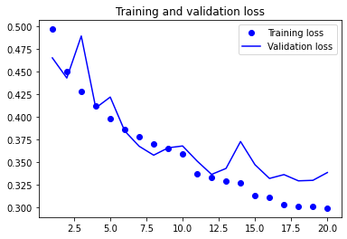

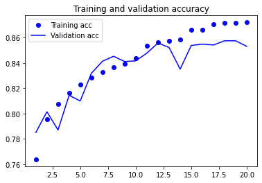

```python
# display the loss and accuracy curves
# https://www.kaggle.com/homayoonkhadivi/medical-diagnosis-histopathologic-cancer-cnn

import matplotlib.pyplot as plt

acc = history.history['accuracy']
val_acc = history.history['val_accuracy']
loss = history.history['loss']
val_loss = history.history['val_loss']

epochs = range(1, len(acc) + 1)

plt.plot(epochs, loss, 'bo', label='Training loss')
plt.plot(epochs, val_loss, 'b', label='Validation loss')
plt.title('Training and validation loss')
plt.legend()
plt.figure()

plt.plot(epochs, acc, 'bo', label='Training acc')
plt.plot(epochs, val_acc, 'b', label='Validation acc')
plt.title('Training and validation accuracy')
plt.legend()
plt.figure()
```

You can see from the plots of training acc vs validation acc that we reached a global peak/valley around 15 epochs. At this point the training a validation accuracy begin to diverge (overfitting). Our model will keep the weights that achieved the highest validation accuracy. Note it is possible that this is a local valley/peak, but 20 epochs took over one hour to perform, so in the interest of saving energy I chose not to run more.

# Setting Up Our Test Data And Directories for Model Prediction

```python
#Testing procedure taken from https://www.kaggle.com/homayoonkhadivi/medical-diagnosis-histopathologic-cancer-cnn

# Transfer the test images into image_dir
test_dir = 'test_dir'
os.mkdir(test_dir)

# create test_images inside test_dir
test_images = os.path.join(test_dir, 'test_images')
os.mkdir(test_images)
# check that the directory we created exists
os.listdir('test_dir')
```

```
['test_images']
```

```python
test_list = os.listdir('../content/test')

for image in test_list:

    fname = image

    # source path to image
    src = os.path.join('../content/test', fname)
    # destination path to image
    dst = os.path.join(test_images, fname)
    # copy the image from the source to the destination
    shutil.copyfile(src, dst)
# check that the images are now in the test_images
# Should now be 57458 images in the test_images folder

len(os.listdir('test_dir/test_images'))
test_path ='test_dir'


# Here we change the path to point to the test_images folder.

test_gen = datagen.flow_from_directory(test_path,
                                        target_size=(IMAGE_SIZE,IMAGE_SIZE),
                                        batch_size=1,
                                        class_mode='categorical',
                                        shuffle=False)
```

```
Found 57458 images belonging to 1 classes.
```

```python
num_test_images = 57458



predictions = cnnmodel.predict_generator(test_gen, steps=num_test_images, verbose=1)
```

```python
df_preds = pd.DataFrame(predictions, columns=['no_tumor_tissue', 'has_tumor_tissue'])

df_preds.head()
```

|  | no_tumor_tissue | has_tumor_tissue |
| --- | --- | --- |
| 0 | 0.000007 | 0.999993 |
| 1 | 0.007357 | 0.992643 |
| 2 | 0.062723 | 0.937277 |
| 3 | 0.118895 | 0.881105 |
| 4 | 0.997320 | 0.002680 |

```python
test_filenames = test_gen.filenames

# add the filenames to the dataframe
df_preds['file_names'] = test_filenames

df_preds.head()
```

|  | no_tumor_tissue | has_tumor_tissue | file_names |
| --- | --- | --- | --- |
| 0 | 0.000007 | 0.999993 | test_images/00006537328c33e284c973d7b39d340809... |
| 1 | 0.007357 | 0.992643 | test_images/0000ec92553fda4ce39889f9226ace43ca... |
| 2 | 0.062723 | 0.937277 | test_images/00024a6dee61f12f7856b0fc6be20bc7a4... |
| 3 | 0.118895 | 0.881105 | test_images/000253dfaa0be9d0d100283b22284ab2f6... |
| 4 | 0.997320 | 0.002680 | test_images/000270442cc15af719583a8172c87cd2bd... |

```python
def extract_id(x):

    # split into a list
    a = x.split('/')
    # split into a list
    b = a[1].split('.')
    extracted_id = b[0]

    return extracted_id

df_preds['id'] = df_preds['file_names'].apply(extract_id)

df_preds.head()
```

|  | no_tumor_tissue | has_tumor_tissue | file_names | id |
| --- | --- | --- | --- | --- |
| 0 | 0.000007 | 0.999993 | test_images/00006537328c33e284c973d7b39d340809... | 00006537328c33e284c973d7b39d340809f7271b |
| 1 | 0.007357 | 0.992643 | test_images/0000ec92553fda4ce39889f9226ace43ca... | 0000ec92553fda4ce39889f9226ace43cae3364e |
| 2 | 0.062723 | 0.937277 | test_images/00024a6dee61f12f7856b0fc6be20bc7a4... | 00024a6dee61f12f7856b0fc6be20bc7a48ba3d2 |
| 3 | 0.118895 | 0.881105 | test_images/000253dfaa0be9d0d100283b22284ab2f6... | 000253dfaa0be9d0d100283b22284ab2f6b643f6 |
| 4 | 0.997320 | 0.002680 | test_images/000270442cc15af719583a8172c87cd2bd... | 000270442cc15af719583a8172c87cd2bd9c7746 |

```python
y_pred = df_preds['has_tumor_tissue']

# get the id column
image_id = df_preds['id']
```

```python
submission = pd.DataFrame({'id':image_id,
                           'label':y_pred,
                          }).set_index('id')

submission.to_csv('patch_preds.csv', columns=['label'])
submission.head()
```

| id | label |
| --- | --- |
| 00006537328c33e284c973d7b39d340809f7271b | 0.999993 |
| 0000ec92553fda4ce39889f9226ace43cae3364e | 0.992643 |
| 00024a6dee61f12f7856b0fc6be20bc7a48ba3d2 | 0.937277 |
| 000253dfaa0be9d0d100283b22284ab2f6b643f6 | 0.881105 |
| 000270442cc15af719583a8172c87cd2bd9c7746 | 0.002680 |

```python
submission.to_csv("submission.csv", index = False, header = True) #submission
```

# Conclusion

My final kaggle score was 0.9104. I would like to experiment further with filter sizes, number of epochs, number of layers, dropout rate, but am happy with my current result. Overall this lab was a great learning experience. It made me feel very humble about the extent of my ML knowledge, and left me excited to learn more and keep experimenting. My first challenge was just to get the data into Colab and run a tf model. Once I figured that out, the challenge was figuring out what model to use as a starting point, given that there are many out there and the keras guide does not recommend starting from scratch. Once I chose a baseline model, I had to choose what to tweak, train/validation split, additional layers, learning rate, optimizers. In the end I settled on the ADAM optimizer and used a feature in Keras that can auto adjust the learning rate. My final accuracy was good at around 91% when I submitted to Kaggle. In the future I would like to get better at doing all of this from scratch without relying so heavily on tutorials. I also want to dive back into the theory and understand better why my final model was better than, for example, the model in the Keras image classification tutorial that is similar to resnet, or why my model is better than an ImageNet pretrained model.

> Please Visit My GitHub Page For the Latest Version: https://github.com/ZZanetti/Kaggle_CancerContest

#### Sources:

- Intro to AI Lectures - CU Boulder 3202
- https://keras.io/api/layers/convolution_layers/convolution2d/
- https://www.tensorflow.org/api_docs/python/tf/keras/layers/Cropping2D
- https://www.kaggle.com/homayoonkhadivi/medical-diagnosis-histopathologic-cancer-cnn
- https://www.kaggle.com/frlemarchand/transfer-learning-for-cancer-detection-keras
- https://towardsdatascience.com/data-preparation-guide-for-detecting-histopathologic-cancer-detection-7b96d6a12004
- https://keras.io/examples/vision/image_classification_from_scratch/#build-a-model

[figure not shown]